# Landfill Geographic Analysis

Charles Taragin and Romeo Ignacio

2024-01-11

### Summary Statistics

# Landfills Market Types

| Type | Count | Percent |
| --- | --- | --- |
| CSA | 4036 | 56 |
| County | 3157 | 44 |

Now Let’s decompose markets that have 1 landfill and > 1 landfill. We see about 59% of markets have only one landfill.

Markets with as least one Landfill

| Type | Count | Percent |
| --- | --- | --- |
| One Landfill | 912 | 59 |
| Several Landfills | 624 | 41 |

Now we will look at summary stats of HHI landfill data on the CSA level. We have 1536 total markets on the CSA level in the dataset but only 1466 analyzed. This can be explained as 70 markets have no waste produced, which produces NAs when calculating for HHI.

CSA HHI Summary Statistics

| Variable | N | Min | Pctile[25] | Median | Pctile[75] | Max | Mean | Sd |
| --- | --- | --- | --- | --- | --- | --- | --- | --- |
| Waste HHI | 1466 | 279 | 7314 | 10000 | 10000 | 10000 | 8446 | 2572 |

Now we will look at summary stats of HHI conditional on if the market is in a CSA or if it’s not.

Market Types

| Type | N | Min | Pctile[25] | Median | Pctile[75] | Max | Mean | Sd |
| --- | --- | --- | --- | --- | --- | --- | --- | --- |
| CSA | 167 | 278.62 | 2095.07 | 3354.92 | 5158.81 | 10000 | 3908.08 | 2305.53 |
| County | 1299 | 821.70 | 9399.90 | 10000.00 | 10000.00 | 10000 | 9029.16 | 1949.07 |

Now let’s look at the deciles of HHIs on the CSA level below:

CSA HHIs

| Type | 0% | 10% | 20% | 30% | 40% | 50% | 60% | 70% | 80% | 90% | 100% |
| --- | --- | --- | --- | --- | --- | --- | --- | --- | --- | --- | --- |
| CSA | 279 | 3924 | 5793 | 8746 | 10000 | 10000 | 10000 | 10000 | 10000 | 10000 | 10000 |

The count of markets on the CSA level is 1536 (including county level markets if no CSA exists).

Now let’s look at the HHIs of only markets with several landfills.

CSA HHIs

| Type | 0% | 10% | 20% | 30% | 40% | 50% | 60% | 70% | 80% | 90% | 100% |
| --- | --- | --- | --- | --- | --- | --- | --- | --- | --- | --- | --- |
| CSA | 279 | 2171 | 3281 | 4252 | 5046 | 5543 | 6571 | 7624 | 8554 | 9414 | 9999 |

### Graphs

Below is a bar-chart of frequency of landfills across markets. About 912 markets across a CSA only have 1 landfill that serves the market. The highest number of firms in a market is 301 in the New York-Newark CSA. 43 of these markets have a firm count greater than 20.

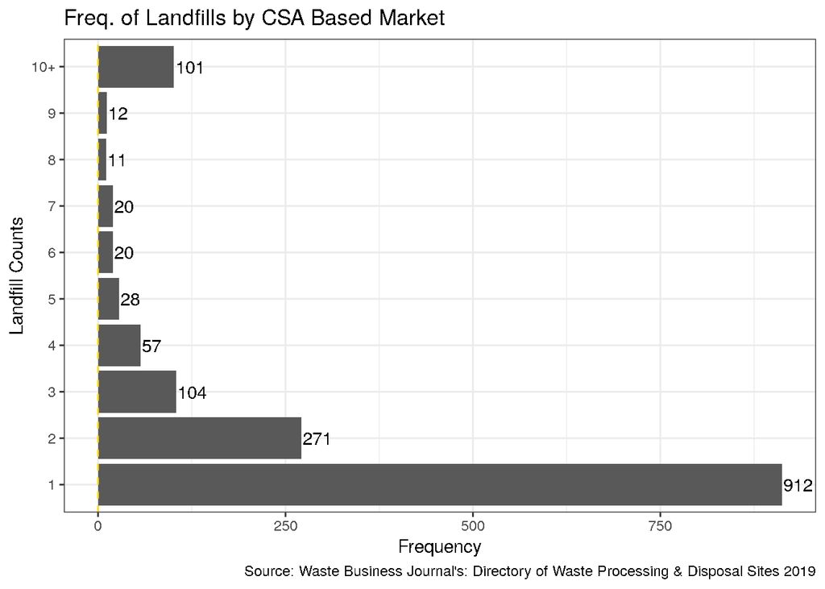